# ADY201m — Cardiovascular disease: analysis and classification

**Data:** `data/cardio_train_raw.csv` — 70,000 patients, 13 columns (11 input features, `ID`, target `CARDIO`), semicolon-separated, `AGE` in days. This notebook reads the **raw** file and converts age exactly once, so it does not depend on the export from notebook 01 and cannot convert age twice.

Contents

1. Setup, data and quality checks
2. Exploratory analysis and visualisation
3. Blood-pressure cleaning with the IQR rule (for EDA and statistics)
4. Statistical tests and OLS (as required by the brief)
5. Modelling: leakage-free pipelines, model comparison, hyper-parameter tuning
6. Evaluation of the selected model
7. Conclusions and limitations

All figures are written to `figures/` and all tables, the trained model and predictions to `results/`.

## 1. Setup, data and quality checks

```python
import json
import platform
import time
from importlib import metadata
from pathlib import Path

import joblib
import matplotlib.pyplot as plt
import numpy as np
import pandas as pd
import seaborn as sns
import statsmodels.api as sm
from IPython.display import display
from matplotlib.colors import LinearSegmentedColormap
from scipy import stats
from sklearn.compose import ColumnTransformer
from sklearn.dummy import DummyClassifier
from sklearn.ensemble import (AdaBoostClassifier, BaggingClassifier, ExtraTreesClassifier,
                              GradientBoostingClassifier, RandomForestClassifier, StackingClassifier)
from sklearn.inspection import permutation_importance
from sklearn.linear_model import RidgeClassifier
from sklearn.metrics import (ConfusionMatrixDisplay, accuracy_score, classification_report, f1_score,
                             precision_score, recall_score, roc_auc_score)
from sklearn.model_selection import GridSearchCV, StratifiedKFold, cross_val_score, train_test_split
from sklearn.neighbors import KNeighborsClassifier
from sklearn.pipeline import Pipeline
from sklearn.preprocessing import StandardScaler

from cardio_utils import (BLOOD_PRESSURE, CATEGORICAL, FEATURES, NUMERIC, TARGET, IQRClipper,
                          age_in_years, iqr_limits, load_raw)

ROOT = Path.cwd()
DATA, FIG, RES = ROOT / "data", ROOT / "figures", ROOT / "results"
FIG.mkdir(exist_ok=True)
RES.mkdir(exist_ok=True)
SEED = 42

NO_COLOR, YES_COLOR, ACCENT = "#2a78d6", "#eb6834", "#1baf7a"
INK, MUTED, GRID = "#0b0b0b", "#52514e", "#e4e3df"
DIVERGING = LinearSegmentedColormap.from_list("blue_gray_red", ["#184f95", "#f0efec", "#b83a3a"])
plt.rcParams.update({
    "figure.dpi": 110, "savefig.dpi": 150, "savefig.bbox": "tight",
    "axes.edgecolor": GRID, "axes.labelcolor": MUTED, "axes.titlecolor": INK,
    "axes.titlesize": 12, "axes.titleweight": "semibold", "axes.grid": True,
    "grid.color": GRID, "grid.linewidth": 0.8, "xtick.color": MUTED, "ytick.color": MUTED,
    "axes.spines.top": False, "axes.spines.right": False, "font.size": 10,
})


def save(fig, name):
    fig.savefig(FIG / name)
    plt.show()


raw = load_raw(DATA / "cardio_train_raw.csv")
df = age_in_years(raw)
df.head(10)
```

|  | ID | AGE | GENDER | HEIGHT | WEIGHT | AP_HI | AP_LO | CHOLESTEROL | GLUC | SMOKE | ALCO | ACTIVE | CARDIO |
| --- | --- | --- | --- | --- | --- | --- | --- | --- | --- | --- | --- | --- | --- |
| 0 | 0 | 50 | 2 | 168 | 62.0 | 110 | 80 | 1 | 1 | 0 | 0 | 1 | 0 |
| 1 | 1 | 55 | 1 | 156 | 85.0 | 140 | 90 | 3 | 1 | 0 | 0 | 1 | 1 |
| 2 | 2 | 51 | 1 | 165 | 64.0 | 130 | 70 | 3 | 1 | 0 | 0 | 0 | 1 |
| 3 | 3 | 48 | 2 | 169 | 82.0 | 150 | 100 | 1 | 1 | 0 | 0 | 1 | 1 |
| 4 | 4 | 47 | 1 | 156 | 56.0 | 100 | 60 | 1 | 1 | 0 | 0 | 0 | 0 |
| 5 | 8 | 60 | 1 | 151 | 67.0 | 120 | 80 | 2 | 2 | 0 | 0 | 0 | 0 |
| 6 | 9 | 60 | 1 | 157 | 93.0 | 130 | 80 | 3 | 1 | 0 | 0 | 1 | 0 |
| 7 | 12 | 61 | 2 | 178 | 95.0 | 130 | 90 | 3 | 3 | 0 | 0 | 1 | 1 |
| 8 | 13 | 48 | 1 | 158 | 71.0 | 110 | 70 | 1 | 1 | 0 | 0 | 1 | 0 |
| 9 | 14 | 54 | 1 | 164 | 68.0 | 110 | 60 | 1 | 1 | 0 | 0 | 0 | 0 |

```python
quality = {
    "rows": len(df),
    "columns": df.shape[1],
    "unique_ids": int(df.ID.nunique()),
    "missing_values": int(df.isna().sum().sum()),
    "duplicate_rows_ignoring_id": int(df.drop(columns="ID").duplicated().sum()),
    "disease_cases": int(df[TARGET].sum()),
    "disease_rate": round(float(df[TARGET].mean()), 4),
    "ap_hi_out_of_range_(<=0_or_>250)": int(((df.AP_HI <= 0) | (df.AP_HI > 250)).sum()),
    "ap_lo_out_of_range_(<=0_or_>200)": int(((df.AP_LO <= 0) | (df.AP_LO > 200)).sum()),
    "ap_lo_greater_than_ap_hi": int((df.AP_LO > df.AP_HI).sum()),
    "height_below_120cm": int((df.HEIGHT < 120).sum()),
    "weight_below_35kg": int((df.WEIGHT < 35).sum()),
}
(RES / "data_quality.json").write_text(json.dumps(quality, indent=2), encoding="utf-8")
pd.Series(quality, name="value").to_frame()
```

|  | value |
| --- | --- |
| rows | 70000.0000 |
| columns | 13.0000 |
| unique_ids | 70000.0000 |
| missing_values | 0.0000 |
| duplicate_rows_ignoring_id | 3208.0000 |
| disease_cases | 34979.0000 |
| disease_rate | 0.4997 |
| ap_hi_out_of_range_(<=0_or_>250) | 47.0000 |
| ap_lo_out_of_range_(<=0_or_>200) | 975.0000 |
| ap_lo_greater_than_ap_hi | 1234.0000 |
| height_below_120cm | 52.0000 |
| weight_below_35kg | 20.0000 |

**Reading the checks:** there are no missing values and every `ID` is unique. Rows that repeat another row's measurements keep their own `ID`; with only 11 coarse features this is plausible for different patients, so they are kept. The blood-pressure columns contain physically impossible values (negative, in the thousands, or diastolic above systolic) — they are treated in section 3.

```python
describe = df[FEATURES + [TARGET]].describe().T
describe.to_csv(RES / "descriptive_statistics.csv")
describe.round(2)
```

|  | count | mean | std | min | 25% | 50% | 75% | max |
| --- | --- | --- | --- | --- | --- | --- | --- | --- |
| AGE | 70000.0 | 52.84 | 6.77 | 29.0 | 48.0 | 53.0 | 58.0 | 64.0 |
| HEIGHT | 70000.0 | 164.36 | 8.21 | 55.0 | 159.0 | 165.0 | 170.0 | 250.0 |
| WEIGHT | 70000.0 | 74.21 | 14.40 | 10.0 | 65.0 | 72.0 | 82.0 | 200.0 |
| AP_HI | 70000.0 | 128.82 | 154.01 | -150.0 | 120.0 | 120.0 | 140.0 | 16020.0 |
| AP_LO | 70000.0 | 96.63 | 188.47 | -70.0 | 80.0 | 80.0 | 90.0 | 11000.0 |
| GENDER | 70000.0 | 1.35 | 0.48 | 1.0 | 1.0 | 1.0 | 2.0 | 2.0 |
| CHOLESTEROL | 70000.0 | 1.37 | 0.68 | 1.0 | 1.0 | 1.0 | 2.0 | 3.0 |
| GLUC | 70000.0 | 1.23 | 0.57 | 1.0 | 1.0 | 1.0 | 1.0 | 3.0 |
| SMOKE | 70000.0 | 0.09 | 0.28 | 0.0 | 0.0 | 0.0 | 0.0 | 1.0 |
| ALCO | 70000.0 | 0.05 | 0.23 | 0.0 | 0.0 | 0.0 | 0.0 | 1.0 |
| ACTIVE | 70000.0 | 0.80 | 0.40 | 0.0 | 1.0 | 1.0 | 1.0 | 1.0 |
| CARDIO | 70000.0 | 0.50 | 0.50 | 0.0 | 0.0 | 0.0 | 1.0 | 1.0 |

## 2. Exploratory analysis and visualisation

Coding: CHOLESTEROL/GLUC 1 = normal, 2 = above normal, 3 = well above normal; SMOKE/ALCO/ACTIVE/CARDIO 0 = no, 1 = yes; GENDER 1 = women, 2 = men.

### Figure 1 — Target distribution

[output not shown]

[output not shown]

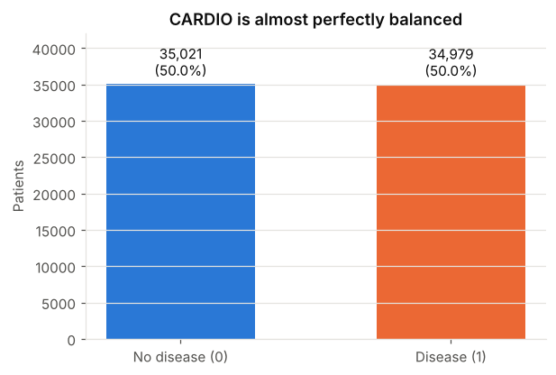

```python
counts = df[TARGET].value_counts().sort_index()
fig, ax = plt.subplots(figsize=(6, 4))
bars = ax.bar(["No disease (0)", "Disease (1)"], counts.values, color=[NO_COLOR, YES_COLOR], width=0.55)
ax.bar_label(bars, labels=[f"{v:,}\n({v / counts.sum():.1%})" for v in counts.values], padding=4, color=INK)
ax.set_ylim(0, counts.max() * 1.2)
ax.set_ylabel("Patients")
ax.set_title("CARDIO is almost perfectly balanced")
ax.grid(axis="x", visible=False)
save(fig, "01_target_distribution.png")
```

### Figure 2 — Correlations before cleaning

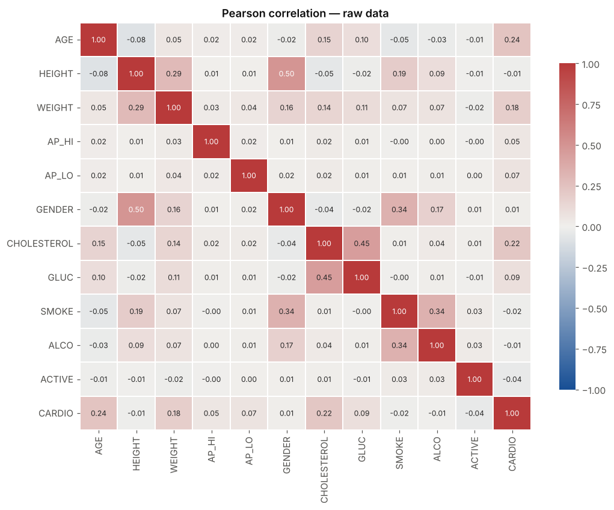

```
AGE            0.238
CHOLESTEROL    0.221
WEIGHT         0.182
GLUC           0.089
AP_LO          0.066
AP_HI          0.054
GENDER         0.008
ALCO          -0.007
HEIGHT        -0.011
SMOKE         -0.015
ACTIVE        -0.036
Name: CARDIO, dtype: float64
```

```python
def corr_heatmap(frame, title, name):
    corr = frame[FEATURES + [TARGET]].corr()
    fig, ax = plt.subplots(figsize=(11, 8))
    sns.heatmap(corr, cmap=DIVERGING, vmin=-1, vmax=1, center=0, annot=True, fmt=".2f",
                linewidths=1, linecolor="white", annot_kws={"size": 8}, cbar_kws={"shrink": 0.8}, ax=ax)
    ax.set_title(title)
    ax.grid(False)
    save(fig, name)
    return corr[TARGET].drop(TARGET).sort_values(ascending=False)


corr_raw = corr_heatmap(df, "Pearson correlation — raw data", "02_correlation_raw.png")
corr_raw.round(3)
```

Before cleaning, AGE, CHOLESTEROL and WEIGHT show the strongest linear association with CARDIO; AP_HI and AP_LO look weak only because a handful of extreme errors dominate their variance.

### Figure 3 — Feature histograms

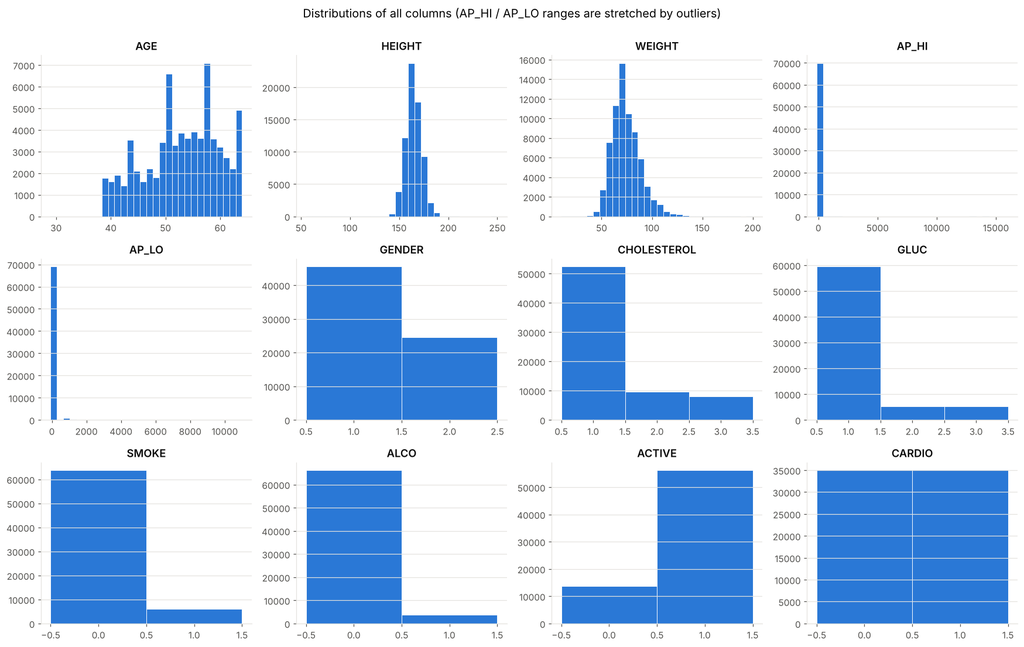

```python
fig, axes = plt.subplots(3, 4, figsize=(16, 10))
for ax, col in zip(axes.flat, FEATURES + [TARGET]):
    ax.hist(df[col], bins=30 if col in NUMERIC else np.arange(df[col].min() - 0.5, df[col].max() + 1.5),
            color=NO_COLOR, edgecolor="white", linewidth=0.6)
    ax.set_title(col)
    ax.grid(axis="x", visible=False)
fig.suptitle("Distributions of all columns (AP_HI / AP_LO ranges are stretched by outliers)", y=1.0, fontsize=13)
fig.tight_layout()
save(fig, "03_histograms.png")
```

### Figure 4 — Disease rate across key features

Instead of a scatter of a 0/1 target, each panel shows the share of patients with CARDIO = 1 per group (the dashed line is the overall rate).

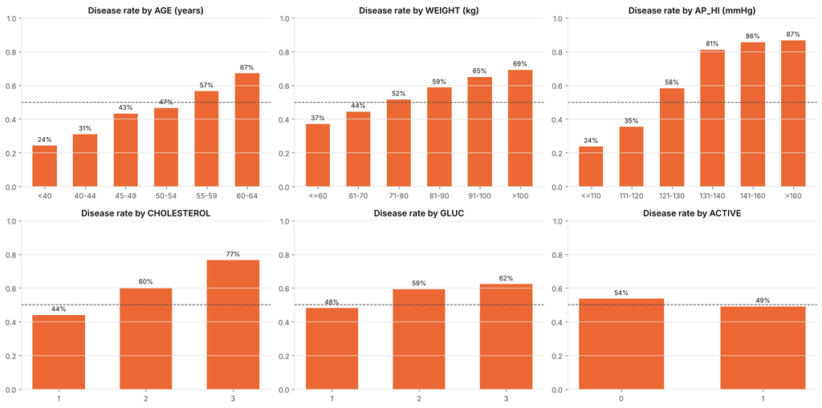

```python
bins = {
    "AGE (years)": pd.cut(df.AGE, [29, 40, 45, 50, 55, 60, 65], right=False,
                          labels=["<40", "40-44", "45-49", "50-54", "55-59", "60-64"]),
    "WEIGHT (kg)": pd.cut(df.WEIGHT, [0, 60, 70, 80, 90, 100, 250],
                          labels=["<=60", "61-70", "71-80", "81-90", "91-100", ">100"]),
    "AP_HI (mmHg)": pd.cut(df.AP_HI, [-np.inf, 110, 120, 130, 140, 160, np.inf],
                           labels=["<=110", "111-120", "121-130", "131-140", "141-160", ">160"]),
    "CHOLESTEROL": df.CHOLESTEROL, "GLUC": df.GLUC, "ACTIVE": df.ACTIVE,
}
overall = df[TARGET].mean()
fig, axes = plt.subplots(2, 3, figsize=(16, 8))
for ax, (name, groups) in zip(axes.flat, bins.items()):
    rate = df.groupby(groups, observed=True)[TARGET].mean()
    labels = [str(i) for i in rate.index]
    bars = ax.bar(labels, rate.values, color=YES_COLOR, width=0.6)
    ax.bar_label(bars, labels=[f"{v:.0%}" for v in rate.values], padding=3, color=INK, fontsize=9)
    ax.axhline(overall, color=MUTED, linestyle="--", linewidth=1)
    ax.set_ylim(0, 1)
    ax.set_title(f"Disease rate by {name}")
    ax.grid(axis="x", visible=False)
fig.tight_layout()
save(fig, "04_disease_rate_by_feature.png")
```

## 3. Blood-pressure cleaning with the IQR rule

For AP_HI and AP_LO: IQR = Q3 − Q1, lower limit = Q1 − 1.5·IQR, upper limit = Q3 + 1.5·IQR. Values outside the limits are **capped** to the nearest limit (rows are kept).

These full-data limits are used **only for EDA and the statistical tests**. In section 5 the same rule lives inside each model pipeline and is learned from the training data alone.

```python
clean = df.copy()
rows = []
for col in BLOOD_PRESSURE:
    low, high = iqr_limits(df[col])
    rows.append({"column": col, "lower": low, "upper": high,
                 "capped_below": int((df[col] < low).sum()), "capped_above": int((df[col] > high).sum())})
    clean[col] = df[col].clip(low, high)
limits = pd.DataFrame(rows)
limits.to_csv(RES / "iqr_limits.csv", index=False)
clean.to_csv(DATA / "cardio_train_clean.csv", index=False)
limits
```

|  | column | lower | upper | capped_below | capped_above |
| --- | --- | --- | --- | --- | --- |
| 0 | AP_HI | 90.0 | 170.0 | 321 | 1114 |
| 1 | AP_LO | 65.0 | 105.0 | 2932 | 1700 |

### Figure 5 — Blood pressure before and after IQR capping

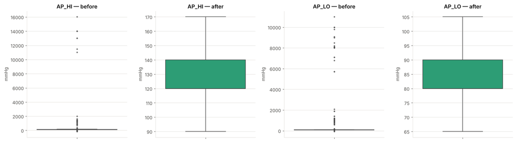

```python
fig, axes = plt.subplots(1, 4, figsize=(16, 4.5))
for i, col in enumerate(BLOOD_PRESSURE):
    for j, (frame, label) in enumerate([(df, "before"), (clean, "after")]):
        ax = axes[i * 2 + j]
        sns.boxplot(y=frame[col], ax=ax, color=NO_COLOR if label == "before" else ACCENT,
                    fliersize=2, linewidth=1)
        ax.set_title(f"{col} — {label}")
        ax.set_ylabel("mmHg")
fig.tight_layout()
save(fig, "05_boxplots_before_after.png")
```

### Figure 6 — Correlations after cleaning

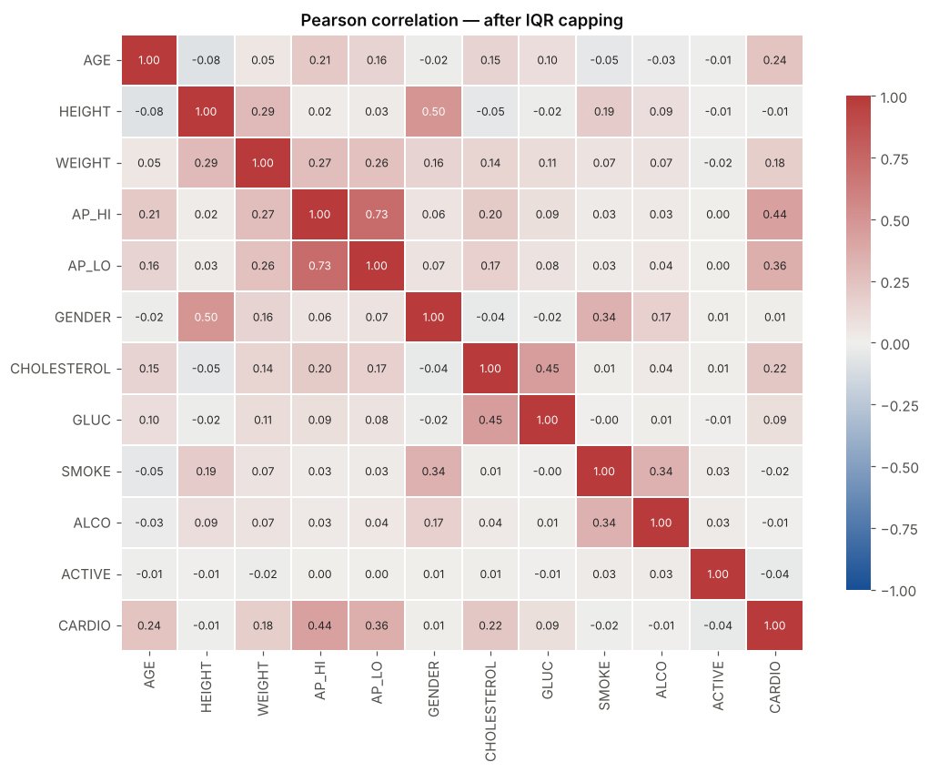

|  | raw | after_IQR |
| --- | --- | --- |
| AP_HI | 0.054 | 0.435 |
| AP_LO | 0.066 | 0.356 |
| AGE | 0.238 | 0.238 |
| CHOLESTEROL | 0.221 | 0.221 |
| WEIGHT | 0.182 | 0.182 |
| GLUC | 0.089 | 0.089 |
| GENDER | 0.008 | 0.008 |
| ALCO | -0.007 | -0.007 |
| HEIGHT | -0.011 | -0.011 |
| SMOKE | -0.015 | -0.015 |
| ACTIVE | -0.036 | -0.036 |

```python
corr_clean = corr_heatmap(clean, "Pearson correlation — after IQR capping", "06_correlation_clean.png")
pd.DataFrame({"raw": corr_raw, "after_IQR": corr_clean}).sort_values("after_IQR", ascending=False).round(3)
```

After capping, **AP_HI becomes the feature most correlated with CARDIO**, followed by AP_LO — the outliers had been hiding the blood-pressure effect.

## 4. Statistical tests (α = 0.05)

Reject H₀ when p < 0.05. With 70,000 rows almost any difference is "significant", so each test also reports an **effect size** to show how large the difference is.

```python
tests = []


def record(name, h0, statistic, p, effect, measure):
    tests.append({"test": name, "H0": h0, "statistic": statistic, "p_value": p,
                  "effect_size": effect, "effect_measure": measure,
                  "decision": "reject H0" if p < 0.05 else "fail to reject H0"})


groups = [clean.loc[clean.CHOLESTEROL == k, TARGET] for k in (1, 2, 3)]
f, p = stats.f_oneway(*groups)
grand = clean[TARGET].mean()
eta2 = sum(len(g) * (g.mean() - grand) ** 2 for g in groups) / ((clean[TARGET] - grand) ** 2).sum()
record("One-way ANOVA: CHOLESTEROL vs CARDIO", "CHOLESTEROL is not related to the disease", f, p, eta2, "eta squared")

younger = clean.loc[clean.AGE < clean.AGE.mean(), TARGET]
older = clean.loc[clean.AGE >= clean.AGE.mean(), TARGET]
lev, lev_p = stats.levene(younger, older, center="mean")
record("Levene: equal variances of CARDIO, younger vs older", "variances are equal", lev, lev_p, np.nan, "")
t, p = stats.ttest_ind(younger, older, equal_var=lev_p > 0.05)
record("Welch t-test: AGE (split at mean) vs CARDIO", "AGE is not related to the disease", t, p,
       older.mean() - younger.mean(), "difference in disease rate (older - younger)")

r, p = stats.pearsonr(clean.WEIGHT, clean[TARGET])
record("Pearson (point-biserial): WEIGHT vs CARDIO", "WEIGHT is not related to the disease", r, p, r, "correlation r")

for col in ["ALCO", "SMOKE", "ACTIVE"]:
    table = pd.crosstab(clean[col], clean[TARGET])
    chi2, p, dof, _ = stats.chi2_contingency(table, correction=True)
    cramers_v = np.sqrt(chi2 / (table.values.sum() * (min(table.shape) - 1)))
    record(f"Chi-square: {col} vs CARDIO", f"{col} is not related to the disease", chi2, p, cramers_v, "Cramer's V")

tests = pd.DataFrame(tests)
tests.to_csv(RES / "statistical_tests.csv", index=False)
pd.set_option("display.max_colwidth", 60)
tests.style.format({"statistic": "{:.3f}", "p_value": "{:.3g}", "effect_size": "{:.4f}"})
```

|  | test | H0 | statistic | p_value | effect_size | effect_measure | decision |
| --- | --- | --- | --- | --- | --- | --- | --- |
| 0 | One-way ANOVA: CHOLESTEROL vs CARDIO | CHOLESTEROL is not related to the disease | 1799.661 | 0 | 0.0489 | eta squared | reject H0 |
| 1 | Levene: equal variances of CARDIO, younger vs older | variances are equal | 133.983 | 5.88e-31 | nan |  | reject H0 |
| 2 | Welch t-test: AGE (split at mean) vs CARDIO | AGE is not related to the disease | -52.514 | 0 | 0.1956 | difference in disease rate (older - younger) | reject H0 |
| 3 | Pearson (point-biserial): WEIGHT vs CARDIO | WEIGHT is not related to the disease | 0.182 | 0 | 0.1817 | correlation r | reject H0 |
| 4 | Chi-square: ALCO vs CARDIO | ALCO is not related to the disease | 3.697 | 0.0545 | 0.0073 | Cramer's V | fail to reject H0 |
| 5 | Chi-square: SMOKE vs CARDIO | SMOKE is not related to the disease | 16.678 | 4.43e-05 | 0.0154 | Cramer's V | reject H0 |
| 6 | Chi-square: ACTIVE vs CARDIO | ACTIVE is not related to the disease | 88.801 | 4.37e-21 | 0.0356 | Cramer's V | reject H0 |

```python
print("Disease rate by group:")
for col in ["ALCO", "SMOKE", "ACTIVE"]:
    print(f"  {col}: " + ", ".join(f"{k}={v:.1%}" for k, v in clean.groupby(col)[TARGET].mean().items()))
```

```
Disease rate by group:
  ALCO: 0=50.1%, 1=48.4%
  SMOKE: 0=50.2%, 1=47.5%
  ACTIVE: 0=53.6%, 1=49.1%
```

**Interpretation**

| Hypothesis | Result | Effect size |
| --- | --- | --- |
| CHOLESTEROL not related | ANOVA F ≈ 1800, p ≈ 0 → **reject H₀** | η² ≈ 0.049 (small–medium): disease rate rises from 44 % to 77 % across levels |
| AGE not related | Levene p < 0.05, so Welch's t-test; t ≈ −52.5, p ≈ 0 → **reject H₀** | older half: +19.6 percentage points disease rate |
| WEIGHT not related | Pearson r ≈ 0.18, p ≈ 0 → **reject H₀** | weak positive correlation |
| ALCO not related | χ² ≈ 3.70, p ≈ 0.055 → **fail to reject H₀** | Cramér's V ≈ 0.007 (negligible) |
| SMOKE not related | χ² ≈ 16.7, p < 0.001 → reject H₀ | V ≈ 0.015 (negligible) |
| ACTIVE not related | χ² ≈ 88.8, p < 0.001 → reject H₀ | V ≈ 0.036 (very small); active patients 49 % vs 54 % |

SMOKE is "significant" only because n is huge: the effect is negligible, and smokers actually show a *lower* rate (47.5 % vs 50.2 %). Smoking is self-reported and concentrated among men, so this is a confounded association, not a protective effect.

### OLS model

A linear probability model on all 11 features (cleaned blood pressure) shows each feature's association with CARDIO while holding the others fixed. It reproduces the brief's statsmodels step; the classifiers in section 5 handle the binary target properly.

```python
ols = sm.OLS(clean[TARGET], sm.add_constant(clean[FEATURES])).fit()
(RES / "ols_summary.txt").write_text(ols.summary().as_text(), encoding="utf-8")
coef = pd.DataFrame({"coef": ols.params, "std_err": ols.bse, "t": ols.tvalues, "p_value": ols.pvalues,
                     "ci_low": ols.conf_int()[0], "ci_high": ols.conf_int()[1]})
coef.to_csv(RES / "ols_coefficients.csv")
print(f"R-squared: {ols.rsquared:.3f}   Adj. R-squared: {ols.rsquared_adj:.3f}   F p-value: {ols.f_pvalue:.3g}")
coef.round(4)
```

```
R-squared: 0.235   Adj. R-squared: 0.235   F p-value: 0
```

|  | coef | std_err | t | p_value | ci_low | ci_high |
| --- | --- | --- | --- | --- | --- | --- |
| const | -1.6708 | 0.0418 | -39.9484 | 0.0000 | -1.7528 | -1.5889 |
| AGE | 0.0101 | 0.0003 | 40.1307 | 0.0000 | 0.0097 | 0.0106 |
| HEIGHT | -0.0008 | 0.0002 | -3.2288 | 0.0012 | -0.0013 | -0.0003 |
| WEIGHT | 0.0021 | 0.0001 | 16.5418 | 0.0000 | 0.0018 | 0.0023 |
| AP_HI | 0.0096 | 0.0002 | 64.3191 | 0.0000 | 0.0094 | 0.0099 |
| AP_LO | 0.0040 | 0.0003 | 14.9933 | 0.0000 | 0.0035 | 0.0045 |
| GENDER | -0.0041 | 0.0042 | -0.9786 | 0.3278 | -0.0123 | 0.0041 |
| CHOLESTEROL | 0.0941 | 0.0028 | 33.6857 | 0.0000 | 0.0886 | 0.0996 |
| GLUC | -0.0207 | 0.0032 | -6.3812 | 0.0000 | -0.0271 | -0.0143 |
| SMOKE | -0.0257 | 0.0065 | -3.9535 | 0.0001 | -0.0385 | -0.0130 |
| ALCO | -0.0379 | 0.0078 | -4.8400 | 0.0000 | -0.0532 | -0.0225 |
| ACTIVE | -0.0437 | 0.0042 | -10.4873 | 0.0000 | -0.0519 | -0.0355 |

**Interpretation:** R² = 0.235. Holding the other features fixed, AP_HI (t ≈ 64), AGE (t ≈ 40), CHOLESTEROL (t ≈ 34), WEIGHT and AP_LO have positive, significant coefficients; ACTIVE is negative (exercise is associated with lower risk). GENDER is not significant (p ≈ 0.33). GLUC, SMOKE and ALCO turn slightly negative once correlated factors (cholesterol, gender) are controlled for — a sign of confounding and self-reporting in this dataset, so these coefficients should not be read causally. The large condition number reflects unscaled features, not a modelling error.

## 5. Modelling

**Split:** 70 % train (49,000) / 30 % test (21,000), stratified on CARDIO, `random_state = 42`. Train/test IDs are saved to `results/`.

**Leakage-free pipeline:** every model is wrapped as `IQRClipper → StandardScaler (numeric columns) → classifier`. Both preprocessing steps learn their parameters inside `fit`, i.e. only from the training data — and only from the training folds during cross-validation.

**Selection rule:** the model is chosen by 3-fold cross-validated accuracy on the training set. The test set is used once, to report the chosen model's performance; the test scores of the other models are shown for comparison only.

```python
X, y = df[FEATURES], df[TARGET]
X_train, X_test, y_train, y_test = train_test_split(X, y, test_size=0.3, stratify=y, random_state=SEED)
pd.DataFrame({"ID": df.loc[X_train.index, "ID"]}).to_csv(RES / "train_ids.csv", index=False)
pd.DataFrame({"ID": df.loc[X_test.index, "ID"]}).to_csv(RES / "test_ids.csv", index=False)
print(f"Train: {X_train.shape}  disease rate {y_train.mean():.3f}")
print(f"Test:  {X_test.shape}  disease rate {y_test.mean():.3f}")


def make_pipeline(model):
    scale = ColumnTransformer([("num", StandardScaler(), NUMERIC)], remainder="passthrough",
                              verbose_feature_names_out=False)
    return Pipeline([("iqr", IQRClipper()), ("scale", scale), ("model", model)])


cv = StratifiedKFold(n_splits=3, shuffle=True, random_state=SEED)
```

```
Train: (49000, 11)  disease rate 0.500
Test:  (21000, 11)  disease rate 0.500
```

### Hyper-parameter tuning of Gradient Boosting

8 combinations × 3 folds on the training set.

```python
grid = GridSearchCV(
    make_pipeline(GradientBoostingClassifier(random_state=SEED)),
    {"model__n_estimators": [100, 200], "model__learning_rate": [0.05, 0.1], "model__max_depth": [3, 4]},
    cv=cv, scoring="accuracy", n_jobs=-1,
)
grid.fit(X_train, y_train)
grid_table = (pd.DataFrame(grid.cv_results_)
              [["params", "mean_test_score", "std_test_score", "rank_test_score", "mean_fit_time"]]
              .sort_values("rank_test_score"))
grid_table.to_csv(RES / "grid_search.csv", index=False)
print("Best parameters:", grid.best_params_)
print(f"Best CV accuracy: {grid.best_score_:.4f}")
grid_table.head(8)
```

```
Best parameters: {'model__learning_rate': 0.05, 'model__max_depth': 4, 'model__n_estimators': 200}
Best CV accuracy: 0.7364
```

|  | params | mean_test_score | std_test_score | rank_test_score | mean_fit_time |
| --- | --- | --- | --- | --- | --- |
| 3 | {'model__learning_rate': 0.05, 'model__max_depth': 4, 'm... | 0.736449 | 0.000788 | 1 | 5.174602 |
| 2 | {'model__learning_rate': 0.05, 'model__max_depth': 4, 'm... | 0.736347 | 0.001202 | 2 | 2.650672 |
| 1 | {'model__learning_rate': 0.05, 'model__max_depth': 3, 'm... | 0.736347 | 0.001940 | 3 | 4.043165 |
| 6 | {'model__learning_rate': 0.1, 'model__max_depth': 4, 'mo... | 0.736347 | 0.001584 | 4 | 2.629187 |
| 7 | {'model__learning_rate': 0.1, 'model__max_depth': 4, 'mo... | 0.736143 | 0.001007 | 5 | 5.126516 |
| 5 | {'model__learning_rate': 0.1, 'model__max_depth': 3, 'mo... | 0.736041 | 0.001345 | 6 | 3.935485 |
| 4 | {'model__learning_rate': 0.1, 'model__max_depth': 3, 'mo... | 0.735837 | 0.001794 | 7 | 1.987039 |
| 0 | {'model__learning_rate': 0.05, 'model__max_depth': 3, 'm... | 0.735551 | 0.001687 | 8 | 2.155744 |

### Model comparison

Each model: 3-fold CV accuracy on the training set, then one fit on the full training set and scores on the test set. A majority-class `DummyClassifier` is the floor every model must beat.

```python
candidates = {
    "Dummy baseline": DummyClassifier(strategy="most_frequent"),
    "RidgeClassifier": RidgeClassifier(alpha=1e-4),
    "RandomForest": RandomForestClassifier(n_estimators=200, random_state=SEED, n_jobs=-1),
    "ExtraTrees": ExtraTreesClassifier(n_estimators=200, random_state=SEED, n_jobs=-1),
    "AdaBoost": AdaBoostClassifier(n_estimators=100, random_state=SEED),
    "Bagging KNN": BaggingClassifier(KNeighborsClassifier(), max_samples=0.5, max_features=0.5,
                                     random_state=SEED, n_jobs=-1),
    "GradientBoosting": GradientBoostingClassifier(random_state=SEED),
    "Stacking": StackingClassifier(
        estimators=[("ridge", RidgeClassifier()), ("knn", KNeighborsClassifier(n_neighbors=20))],
        final_estimator=GradientBoostingClassifier(n_estimators=25, subsample=0.5, min_samples_leaf=25,
                                                   max_features=1, random_state=SEED),
        n_jobs=-1),
}


def scores(pipe):
    pred = pipe.predict(X_test)
    if hasattr(pipe, "predict_proba"):
        score = pipe.predict_proba(X_test)[:, 1]
    else:
        score = pipe.decision_function(X_test)
    return pred, score, {
        "test_accuracy": accuracy_score(y_test, pred),
        "precision": precision_score(y_test, pred, zero_division=0),
        "recall": recall_score(y_test, pred),
        "f1": f1_score(y_test, pred),
        "roc_auc": roc_auc_score(y_test, score),
    }


fitted, predictions, rows = {}, {}, []
for name, model in candidates.items():
    start = time.perf_counter()
    pipe = make_pipeline(model)
    cv_acc = cross_val_score(pipe, X_train, y_train, cv=cv, scoring="accuracy", n_jobs=-1).mean()
    pipe.fit(X_train, y_train)
    pred, score, metrics = scores(pipe)
    fitted[name], predictions[name] = pipe, (pred, score)
    rows.append({"model": name, "cv_accuracy": cv_acc, **metrics, "seconds": time.perf_counter() - start})
    print(f"{name:<22} CV {cv_acc:.4f}   test {metrics['test_accuracy']:.4f}")

tuned = grid.best_estimator_
pred, score, metrics = scores(tuned)
fitted["GradientBoosting tuned"], predictions["GradientBoosting tuned"] = tuned, (pred, score)
rows.append({"model": "GradientBoosting tuned", "cv_accuracy": grid.best_score_, **metrics, "seconds": np.nan})

comparison = pd.DataFrame(rows).sort_values("cv_accuracy", ascending=False).reset_index(drop=True)
comparison.to_csv(RES / "model_comparison.csv", index=False)
selected = comparison.loc[0, "model"]
print("\nSelected by CV accuracy:", selected)
comparison.round(4)
```

```
Dummy baseline         CV 0.5003   test 0.5003
```

```
RidgeClassifier        CV 0.7281   test 0.7241
```

```
RandomForest           CV 0.7105   test 0.7096
```

```
ExtraTrees             CV 0.6962   test 0.6936
```

```
AdaBoost               CV 0.7304   test 0.7259
```

```
Bagging KNN            CV 0.7210   test 0.7184
```

```
GradientBoosting       CV 0.7358   test 0.7317
```

```
Stacking               CV 0.7311   test 0.7291

Selected by CV accuracy: GradientBoosting tuned
```

|  | model | cv_accuracy | test_accuracy | precision | recall | f1 | roc_auc | seconds |
| --- | --- | --- | --- | --- | --- | --- | --- | --- |
| 0 | GradientBoosting tuned | 0.7364 | 0.7336 | 0.7525 | 0.6957 | 0.7230 | 0.8003 | NaN |
| 1 | GradientBoosting | 0.7358 | 0.7317 | 0.7486 | 0.6972 | 0.7220 | 0.7995 | 7.4053 |
| 2 | Stacking | 0.7311 | 0.7291 | 0.7431 | 0.7000 | 0.7209 | 0.7921 | 18.3221 |
| 3 | AdaBoost | 0.7304 | 0.7259 | 0.7651 | 0.6515 | 0.7038 | 0.7926 | 4.0268 |
| 4 | RidgeClassifier | 0.7281 | 0.7241 | 0.7558 | 0.6616 | 0.7056 | 0.7865 | 0.2930 |
| 5 | Bagging KNN | 0.7210 | 0.7184 | 0.7414 | 0.6704 | 0.7041 | 0.7776 | 5.8950 |
| 6 | RandomForest | 0.7105 | 0.7096 | 0.7118 | 0.7040 | 0.7079 | 0.7667 | 15.4875 |
| 7 | ExtraTrees | 0.6962 | 0.6936 | 0.6950 | 0.6894 | 0.6922 | 0.7415 | 16.7596 |
| 8 | Dummy baseline | 0.5003 | 0.5003 | 0.0000 | 0.0000 | 0.0000 | 0.5000 | 0.1532 |

### Figure 7 — Model comparison

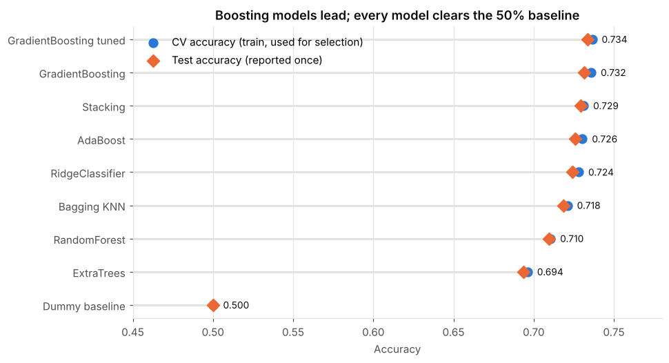

```python
plot = comparison.sort_values("cv_accuracy")
fig, ax = plt.subplots(figsize=(9, 5))
y_pos = np.arange(len(plot))
ax.hlines(y_pos, 0.45, plot.cv_accuracy, color=GRID, linewidth=2)
ax.scatter(plot.cv_accuracy, y_pos, color=NO_COLOR, s=70, zorder=3, label="CV accuracy (train, used for selection)")
ax.scatter(plot.test_accuracy, y_pos, color=YES_COLOR, s=70, marker="D", zorder=3, label="Test accuracy (reported once)")
for yp, (cvv, tv) in enumerate(zip(plot.cv_accuracy, plot.test_accuracy)):
    ax.text(max(cvv, tv) + 0.006, yp, f"{tv:.3f}", va="center", color=INK, fontsize=9)
ax.set_yticks(y_pos, plot.model)
ax.set_xlim(0.45, 0.78)
ax.set_xlabel("Accuracy")
ax.set_title("Boosting models lead; every model clears the 50% baseline")
ax.legend(loc="upper left", frameon=False)
ax.grid(axis="y", visible=False)
save(fig, "07_model_comparison.png")
```

## 6. Evaluation of the selected model

```python
model = fitted[selected]
pred, score = predictions[selected]
print("Selected model:", selected)
if selected == "GradientBoosting tuned":
    print("Parameters:", grid.best_params_)
print()
print(classification_report(y_test, pred, target_names=["No disease", "Disease"], digits=4))
```

```
Selected model: GradientBoosting tuned
Parameters: {'model__learning_rate': 0.05, 'model__max_depth': 4, 'model__n_estimators': 200}

              precision    recall  f1-score   support

  No disease     0.7174    0.7715    0.7434     10506
     Disease     0.7525    0.6957    0.7230     10494

    accuracy                         0.7336     21000
   macro avg     0.7350    0.7336    0.7332     21000
weighted avg     0.7349    0.7336    0.7332     21000
```

### Figure 8 — Confusion matrix (test set)

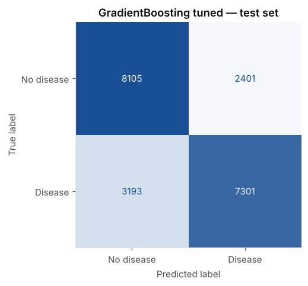

```python
fig, ax = plt.subplots(figsize=(5.5, 4.5))
ConfusionMatrixDisplay.from_predictions(
    y_test, pred, display_labels=["No disease", "Disease"],
    cmap=LinearSegmentedColormap.from_list("blue", ["#f4f8fd", "#184f95"]), colorbar=False, ax=ax)
ax.set_title(f"{selected} — test set")
ax.grid(False)
save(fig, "08_confusion_matrix.png")
```

### Figure 9 — Feature importance

Permutation importance on the test set: how much accuracy drops when one feature is shuffled. It is model-agnostic and measured on unseen data.

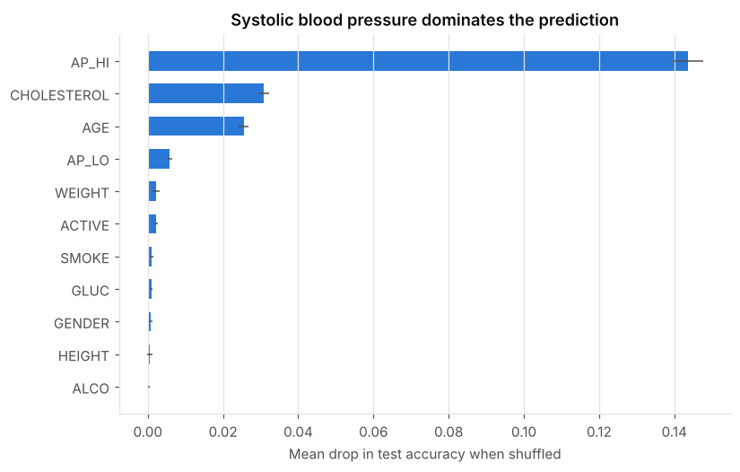

|  | feature | importance_mean | importance_std |
| --- | --- | --- | --- |
| 3 | AP_HI | 0.1437 | 0.0039 |
| 6 | CHOLESTEROL | 0.0308 | 0.0014 |
| 0 | AGE | 0.0255 | 0.0013 |
| 4 | AP_LO | 0.0058 | 0.0006 |
| 2 | WEIGHT | 0.0022 | 0.0010 |
| 10 | ACTIVE | 0.0021 | 0.0005 |
| 8 | SMOKE | 0.0009 | 0.0005 |
| 7 | GLUC | 0.0009 | 0.0003 |
| 5 | GENDER | 0.0007 | 0.0004 |
| 1 | HEIGHT | 0.0004 | 0.0007 |
| 9 | ALCO | 0.0003 | 0.0003 |

```python
perm = permutation_importance(model, X_test, y_test, scoring="accuracy", n_repeats=10,
                              random_state=SEED, n_jobs=-1)
importance = (pd.DataFrame({"feature": FEATURES, "importance_mean": perm.importances_mean,
                            "importance_std": perm.importances_std})
              .sort_values("importance_mean", ascending=False))
importance.to_csv(RES / "feature_importance.csv", index=False)

plot = importance.sort_values("importance_mean")
fig, ax = plt.subplots(figsize=(8, 5))
ax.barh(plot.feature, plot.importance_mean, xerr=plot.importance_std, color=NO_COLOR, height=0.6,
        error_kw={"ecolor": MUTED, "elinewidth": 1})
ax.set_xlabel("Mean drop in test accuracy when shuffled")
ax.set_title("Systolic blood pressure dominates the prediction")
ax.grid(axis="y", visible=False)
save(fig, "09_feature_importance.png")
importance.round(4)
```

### Save the model, predictions and run summary

```python
joblib.dump(model, RES / "cardio_classifier.joblib")
pd.DataFrame({"ID": df.loc[X_test.index, "ID"].values, "y_true": y_test.values, "y_pred": pred,
              "score": score}).to_csv(RES / "test_predictions.csv", index=False)

packages = ["numpy", "pandas", "scipy", "scikit-learn", "statsmodels", "matplotlib", "seaborn", "joblib"]
versions = pd.DataFrame([{"package": "python", "version": platform.python_version()}] +
                        [{"package": p, "version": metadata.version(p)} for p in packages])
versions.to_csv(RES / "environment_versions.csv", index=False)

chosen = comparison.set_index("model").loc[selected]
summary = {
    "quality": quality,
    "iqr_limits_full_data": limits.set_index("column")[["lower", "upper"]].to_dict("index"),
    "split": {"train": len(X_train), "test": len(X_test), "stratified": True, "random_state": SEED},
    "selection_rule": "highest 3-fold CV accuracy on the training set",
    "selected_model": selected,
    "best_params": grid.best_params_ if selected == "GradientBoosting tuned" else None,
    "cv_accuracy": round(float(chosen.cv_accuracy), 4),
    "test_metrics": {k: round(float(chosen[k]), 4) for k in ["test_accuracy", "precision", "recall", "f1", "roc_auc"]},
    "top_features": importance.feature.head(5).tolist(),
}
(RES / "summary.json").write_text(json.dumps(summary, indent=2, default=str), encoding="utf-8")
summary
```

```
{'quality': {'rows': 70000,
  'columns': 13,
  'unique_ids': 70000,
  'missing_values': 0,
  'duplicate_rows_ignoring_id': 3208,
  'disease_cases': 34979,
  'disease_rate': 0.4997,
  'ap_hi_out_of_range_(<=0_or_>250)': 47,
  'ap_lo_out_of_range_(<=0_or_>200)': 975,
  'ap_lo_greater_than_ap_hi': 1234,
  'height_below_120cm': 52,
  'weight_below_35kg': 20},
 'iqr_limits_full_data': {'AP_HI': {'lower': 90.0, 'upper': 170.0},
  'AP_LO': {'lower': 65.0, 'upper': 105.0}},
 'split': {'train': 49000,
  'test': 21000,
  'stratified': True,
  'random_state': 42},
 'selection_rule': 'highest 3-fold CV accuracy on the training set',
 'selected_model': 'GradientBoosting tuned',
 'best_params': {'model__learning_rate': 0.05,
  'model__max_depth': 4,
  'model__n_estimators': 200},
 'cv_accuracy': 0.7364,
 'test_metrics': {'test_accuracy': 0.7336,
  'precision': 0.7525,
  'recall': 0.6957,
  'f1': 0.723,
  'roc_auc': 0.8003},
 'top_features': ['AP_HI', 'CHOLESTEROL', 'AGE', 'AP_LO', 'WEIGHT']}
```

## 7. Conclusions and limitations

**Findings**

**Limitations**

- Tests show statistical association on observational data, not causation; with 70,000 rows, p-values must be read together with effect sizes.
- SMOKE, ALCO and ACTIVE are self-reported, and some rows remain implausible after capping (e.g. heights below 120 cm), which caps achievable accuracy around 73–74 %.
- Missing a sick patient is costlier than a false alarm; in practice the decision threshold should be lowered to raise recall (0.70 now) at the expense of precision.
- The model is for coursework only and has not been validated for clinical use.